# Learn IRT by doing: the mirtverse labs

Source: [`vignettes/articles/labs.Rmd`](https://github.com/okanbulut/mirtverse/blob/main/vignettes/articles/labs.Rmd)

Reading about item response theory is one thing; deciding what to do with a real test is another. The mirtverse labs put students in the analyst’s chair. Each lab is an interactive tutorial that runs in the browser. Students write and run live mirt code, look at the results, and make the calls a working psychometrician makes. Every decision gets immediate feedback that explains why the choice holds up or doesn’t.

## Start a lab in three steps

```r
install.packages("learnr")   # 1. once, if you don't have it
library(mirtverse)           # 2. load mirtverse
run_lab("model-choice")      # 3. open Lab 1 in your browser
```

`list_labs()` shows every lab with a short description. In RStudio, the labs also appear in the **Tutorial** pane. Your progress is saved on your computer, so you can close the lab and pick up where you left off.

## The story

You are the new psychometrician for the fictional Northfield Certification Board. Its 32-item exam was taken by 1,200 candidates in English or French, and the board wants to move to IRT scoring. The data (`certexam`) were simulated, so the truth is known, and a few realistic problems are hidden in them for you to find.

[output not shown]

Lab 2 fits its own model at the start, so it can be done on its own.

## What it looks like

Each section mixes short explanations, code exercises with hints and solutions, and decision questions. At the end of each lab, you get a table of every decision you made, which you can hand in as an assignment.

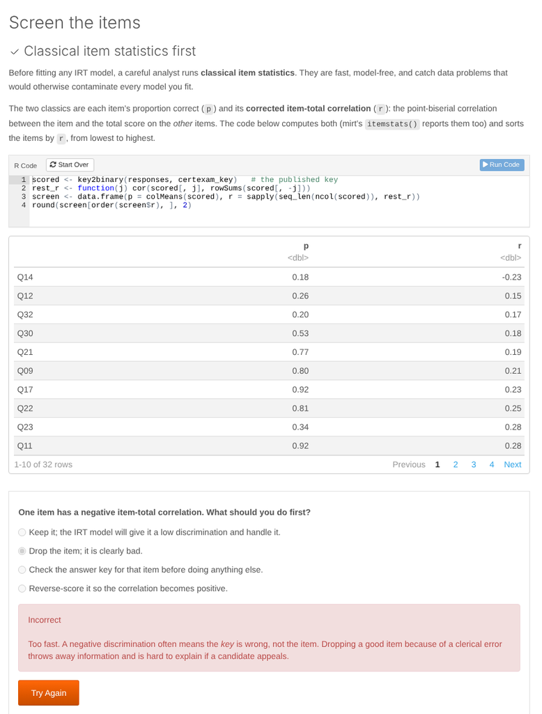

## For instructors

The instructor guide has the planted problems, the answer key for every decision, discussion prompts, and tips on hosting the labs online so students need nothing installed. `lab_truth()` returns the values used to simulate the data.